# 1. Teoría de grafos

# Conceptos fundamentales de teoría de grafos

# Grafos y subgrafos

Un **grafo** $G = (V, E)$ es una estructura que que se compone por un conjunto de **vértices** (nodos) $V$ y de un conjunto de **aristas** (enlaces o *edge*) $E$, donde los elementos de $E$ son parejas de la forma $e=\{u,v\}$, con $u,v\in V$.

> Los grafos son el objeto matemático que usamos para representar las redes complejas.

Decimos que un grafo $G'=(V',E')$ es un **subgrafo** de $G=(V,E)$ si $V'\subset V$ y $E'\subset E$.

# Isomorfismo

Dos grafos que son **equivalentes estructuralmente** (a pesar de las etiquetas de los vértices) se denominan **isomorfos**.

Dos grafos $G_1 = (V_1, E_1)$ y $G_2 = (V_2, E_2)$ son **isomorfos**, lo que se escribe $G_1 \equiv G_2$, si existe una biyección $\varphi:V_1\longrightarrow V_2$ tal que $\{u,v\}\in E_1$ si y solo si $\{\varphi(u),\varphi(v)\}\in E_2$.

Si $G_1 \equiv G_2$, entonces $|V_1| = |V_2|$ y $|E_1| = |E_2|$.

Si $|V_1| \neq |V_2|$ o $|E_1| \neq |E_2|$, entonces $G_1 \not\equiv G_2$.

Si $G_1 \equiv G_2$ y $\{u,v\}\notin E_1$, entonces $\{\varphi(u),\varphi(v)\}\notin E_2$.

Para ilustrar la definición, consideremos dos grafos arbitrarios y evaluemos si son *isomorfos*

```r
suppressMessages(suppressWarnings(library(igraph)))
# grafos
g1 <- graph_from_literal(0-1, 1-2, 2-3, 3-4, 4-0)
g2 <- graph_from_literal(a-c, a-d, b-d, b-e, c-e)
```

Como puede verse, las conexiones y el número de vértices son equivalentes, por lo que podemos afirmar que se trata de dos grafos isomorfos

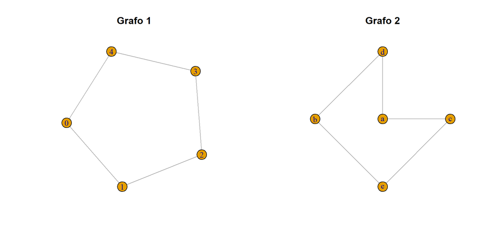

```r
# visualización
set.seed(123)
par(mfrow = c(1,2))
plot(g1, vertex.size = 15, main = "Grafo 1")
plot(g2, vertex.size = 15, main = "Grafo 2", layout = layout_as_star)
```

En estructuras mas complejas resulta conveniente contar con alguna herramienta de evaluación de isomofismo, lo que nos proporciona la función *isomorphic()* la cual nos da como salida un valor lógico o booleano.

```r
isomorphic(g1, g2)
```

```
## [1] TRUE
```

# Adyacencia

Se dice que dos vértices $u, v \in V$ son **adyacentes** (*adjacent*), lo que se denota con $u\sim v$, si $u$ y $v$ están conectados por alguna arista de $E$.

Para valorar la adyacencia tomemos un grafo arbitrario y valoremos los vecinos del vertice 1, que en este caso son los vertices 2 y 3.

```r
g <- graph(edges = c(1,2, 1,3, 2,3, 2,4, 3,5, 4,5, 4,6, 4,7, 5,6, 6,7), directed = FALSE)

neighbors(graph = g,v = 1)
```

```
## + 2/7 vertices, from 873cf90:
## [1] 2 3
```

Por su parte, un vértice $v\in V$ se llama **asilado** (*isolated*) si $v\not\sim u$ para todo $u\in V$, es deci, si no es adyacente a ningún otro nodo. De esto podemos inferir que Un grafo se puede almacenar por medio de una matriz de aristas (que muestra todos enlaces) y una lista de vértices aislados.

Finalmente, un vértice $v \in V$ es **incidente** (*incident*) en una arista $e\in E$ si $e = \{v,u\}$ para algún $u\in V$.

## Grado de un grafo

El **grado** (*degree*) de un vértice $v\in V$ se define como el número de aristas incidentes en $v$. En nuestro caso, con un grafo no dirigido, podemos ver el grado de cada vértice evaluando sus vértices incidentes con la función *degree()*. Nótese que podriamos valorar los vértices incidentes por cada vector con la función de vecindad *neighbors()*.

```r
neighbors(graph = g, v = 4)
```

```
## + 4/7 vertices, from 873cf90:
## [1] 2 5 6 7
```

```r
degree(graph = g)
```

```
## [1] 2 3 3 4 3 3 2
```

Es interesante notar que el grado de los vectores nos ofrecen una **distribución de masa de probabildad** (que usamos para variables discretas), que denominaremos *distribución de grado*, el cual es de las primeras caracteristicas que valoramos al estudiar grafos.

> Por lo general, la distribución de **grado de un grafo** siguen patrones particulares que estudiaremos mas adelante.

Para dígrafos, el **grado de entrada** (*in-degree*) y el **grado de salida** (*out-degree*) del vértice $v\in V$ se definen como el número de aristas que apuntan hacia dentro y hacia fuera de $v$, respectivamente.

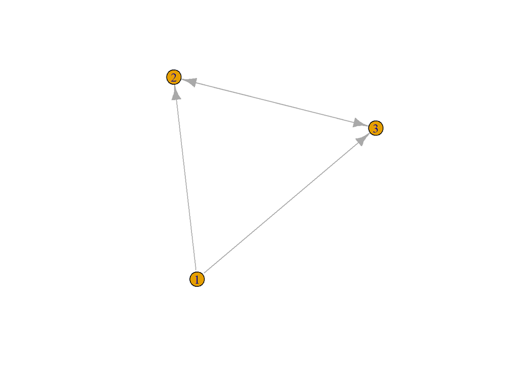

```r
# red dirigida
dg <- graph_from_literal(1-+2, 1-+3, 2++3)

set.seed(123)
plot(dg)
```

Veamos ahora los grados de entrada y de salida de cada vértice

```r
print("Grado de entrada"); degree(graph = dg, mode = "in")
```

```
## [1] "Grado de entrada"
```

```
## 1 2 3
## 0 2 2
```

```r
print("Grado de salida"); degree(graph = dg, mode = "out")
```

```
## [1] "Grado de salida"
```

```
## 1 2 3
## 2 1 1
```

## Movimiento de un gráfo

Una **caminata** (*walk*) de $v_0$ a $v_\ell$ de longitud $\ell$ es una secuencia alternante de vertices $v_i$ y enlaces $e_i$ $\{v_0,e_1,v_1,e_2,v_2,\ldots,v_{\ell-1},e_\ell,v_\ell\}$ en la que los puntos extremos de $e_i$ son $\{v_{i-1}, v_i\}$, con $i=1,\ldots,\ell$ (se pueden repetir vértices y aristas) se dice que la longitud de esta caminata es $\ell$. Puede haber caminatas abiertas o cerradas.

- $1\rightarrow 2\rightarrow 3\rightarrow 4\rightarrow 3\,$ es una **caminata abierta**, dado que el vértice de inicio no coincide con el final.
- $1\rightarrow 2\rightarrow 3\rightarrow 4\rightarrow 3\rightarrow 1\,$ es una **caminata cerrada**.

Un **sendero** (*trail*) es una caminata abierta sin aristas repetidas (se pueden repetir vértices).

- $1\rightarrow 3\rightarrow 8\rightarrow 6\rightarrow 3\rightarrow 2\,$ es un **sendero**.

Un **circuito** (*circuit*) es una caminata cerrada sin aristas repetidas (se pueden repetir vértices).

- $1\rightarrow 2\rightarrow 4\rightarrow 3\rightarrow 6\rightarrow 8\rightarrow 3\rightarrow 1\,$ es un **circuito**.

Un **ciclo** (*cycle*) es una caminata cerrada con al menos tres aristas no repetidas y vértices intermedios distintos.

- $1\rightarrow 2\rightarrow 4\rightarrow 3\rightarrow 1\,$ es un ciclo.

Los grafos que no contienen ciclos se denominan **acíclicos** (*acycle*).

## Conectividad y componentes

Se dice que un vértice $v$ es **accesible** (*reachable*) desde otro vértice $u$ si existe una caminata desde $u$ hasta $v$.

Se dice que un grafo está **conectado** (*connected*) si cada vértice es accesible desde todos los demás.

Una **componente** (*component*) de un grafo es un subgrafo conectado maximalmente, i.e., un subgrafo al que añadirle cualquier otro vértice arruina la conectividad.

Veamos un ejemplo con un grafo de tres componentes

```r
# red no dirigida
g <- graph_from_literal(1-7, 2-7, 2-4, 3-6, 4-7, 5-11, 6-12, 7-8, 7-9, 7-10)
```

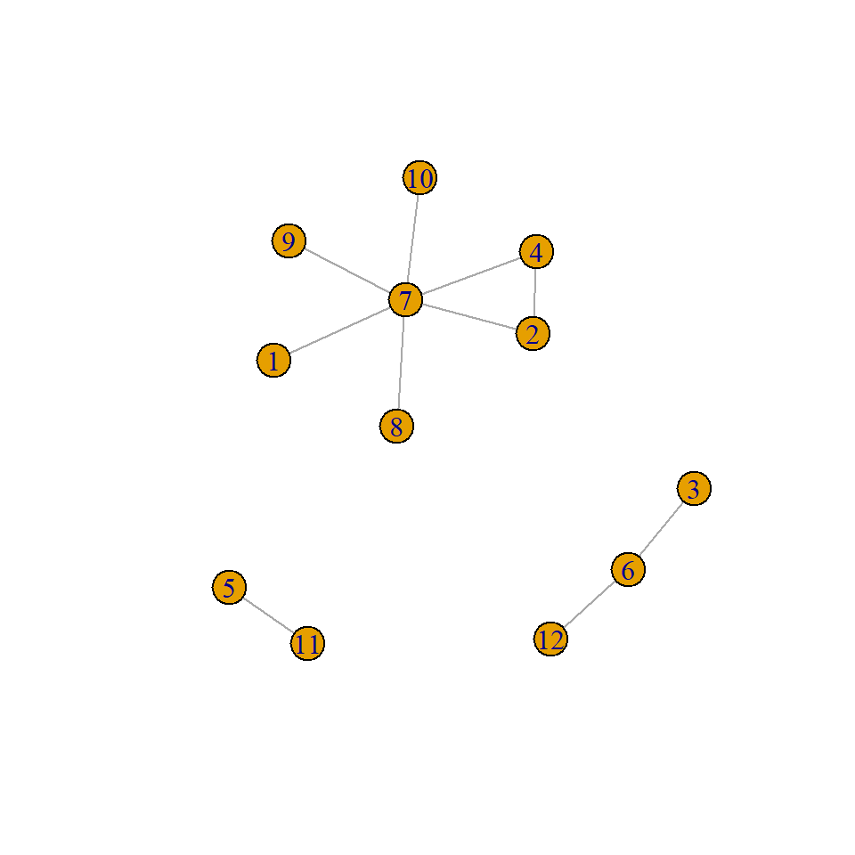

```r
# visualización
set.seed(123)
plot(g)
```

Nos preguntamos si el grafo está conectado *(connected)*, es decir, si todos los vértices están conectads. Lo que sabemos que no es cierto.

```r
# conectado?
is_connected(g)
```

```
## [1] FALSE
```

Habiendo definido que nuestro grafo no está conectado, preguntemonos por el número de componentes. Con la rutina *clusters()* aparecen tres mensajes:

1. A qué componente pertenece cada vector
2. Tamaño de cada uno de los componentes
3. Cuántos componentes existen

```r
# componentes
clusters(g)
```

```
## $membership
##  1  7  2  4  3  6  5 11 12  8  9 10
##  1  1  1  1  2  2  3  3  2  1  1  1
##
## $csize
## [1] 7 3 2
##
## $no
## [1] 3
```

Un digrafo está **conectado débilmente** (*weakly connected*) si el grafo subyacente (resultado de remover la direccionalidad) está conectado.

Un digrafo está **conectado fuertemente** (*strongly connected*) si cada vértice es accesible desde todos los demás mediante una caminata dirigida.

## Ejemplo

```r
# red dirigida
dg <- graph_from_literal(1-+2, 1-+3, 2++3)
```

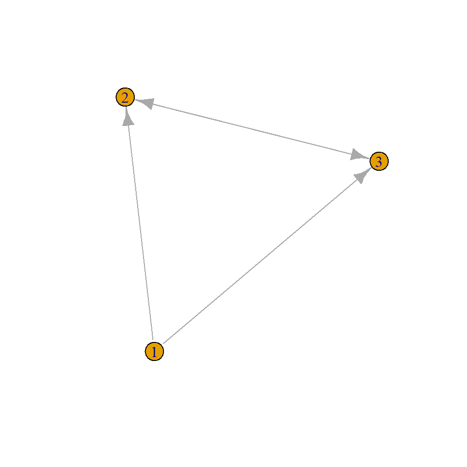

```r
# visualización
set.seed(123)
plot(dg)
```

```r
# conectado débilmente?
is_connected(graph = dg, mode = "weak")
```

```
## [1] TRUE
```

```r
# conectado fuertemente?
is_connected(graph = dg, mode = "strong")
```

```
## [1] FALSE
```

# Distancia

La **distancia geodésica** entre dos vértices de un grafo es la longitud de la caminata más corta entre los vértices.

La distancia se define como infinito si no existen caminatas entre los vértices.

El valor de la distancia más grande de un grafo se llama **diámetro** del grafo.

La **distancia geodésica promedio** es una medida del grado de separación de los vértices.

## Ejemplo

```r
# red no dirigida
g <- graph_from_literal(1-2, 1-3, 2-3, 2-4, 3-5, 4-5, 4-6, 4-7, 5-6, 6-7)
```

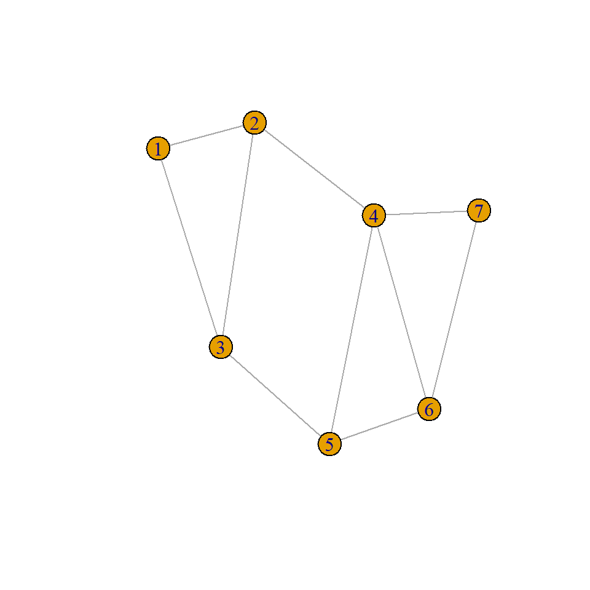

```r
# visualización
set.seed(123)
plot(g)
```

```r
# distancia
distances(graph = g, v = 1, to = 6)
```

```
##   6
## 1 3
```

```r
# caminata
shortest_paths(graph = g, from = 1, to = 6)$vpath
```

```
## [[1]]
## + 4/7 vertices, named, from 8805021:
## [1] 1 2 4 6
```

```r
# caminatas
all_shortest_paths(graph = g, from = 1, to = 6)$res
```

```
## [[1]]
## + 4/7 vertices, named, from 8805021:
## [1] 1 3 5 6
##
## [[2]]
## + 4/7 vertices, named, from 8805021:
## [1] 1 2 4 6
```

```r
# distancias
(D <- distances(graph = g, v = V(g), to = V(g)))
```

```
##   1 2 3 4 5 6 7
## 1 0 1 1 2 2 3 3
## 2 1 0 1 1 2 2 2
## 3 1 1 0 2 1 2 3
## 4 2 1 2 0 1 1 1
## 5 2 2 1 1 0 1 2
## 6 3 2 2 1 1 0 1
## 7 3 2 3 1 2 1 0
```

```r
# diámetro
diameter(g)
```

```
## [1] 3
```

```r
# diámetro (otra manera)
max(D[lower.tri(D)])
```

```
## [1] 3
```

```r
# sendero del diámetro
(d <- get_diameter(g))
```

```
## + 4/7 vertices, named, from 8805021:
## [1] 1 2 4 6
```

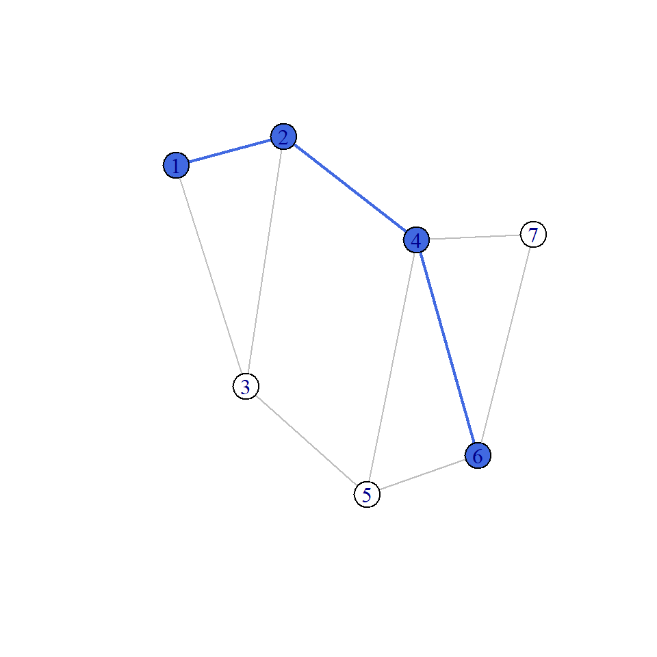

```r
# visualización del diámetro
V(g)$color <- "white"
E(g)$color <- "grey"
E(g)$width <- 1
V(g)[d]$color <- "royalblue"
E(g, path = d)$color <- "royalblue"
E(g, path = d)$width <- 2
set.seed(123)
plot(g)
```

```r
# distancia geodésica promedio
mean_distance(g)
```

```
## [1] 1.666667
```

```r
# distancia geodésica promedio (otra manera)
mean(D[lower.tri(D)])
```

```
## [1] 1.666667
```

```r
# distribución de las distancias
distance_table(g)
```

```
## $res
## [1] 10  8  3
##
## $unconnected
## [1] 0
```

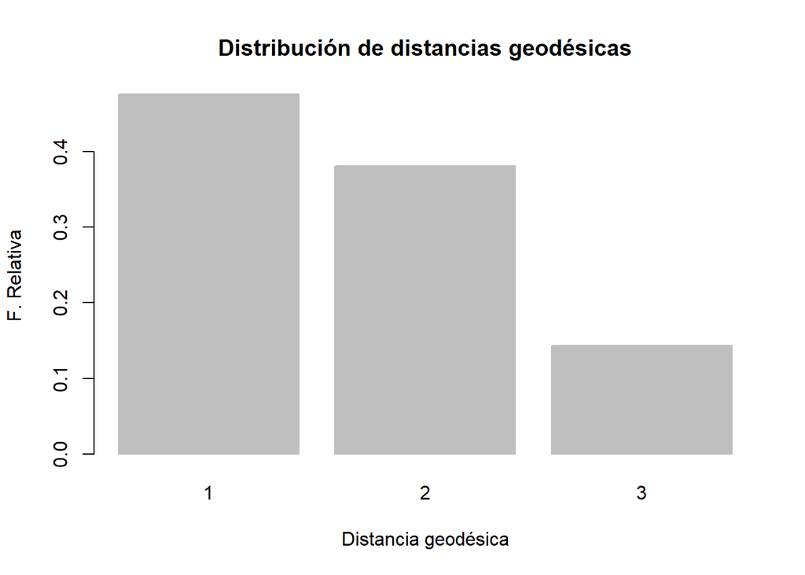

```r
# visualización
senderos <- distance_table(g)$res
names(senderos) <- 1:length(senderos)
barplot(prop.table(senderos), xlab = "Distancia geodésica", ylab = "F. Relativa", border = "grey", col = "grey", main = "Distribución de distancias geodésicas")
```